# An Analysis of Global Life Expectancy Trends

Ranbeer Rai

2025-10-09

## **1. Introduction:**

The topic of this project is global life expectancy and its relationship with factors like sex, geographical region, and major global health events. Life expectancy is a key indicator of a population’s overall health, reflecting the impact of healthcare, socio-economic conditions, and global crises. This analysis uses data from the World Health Organization to explore these trends.

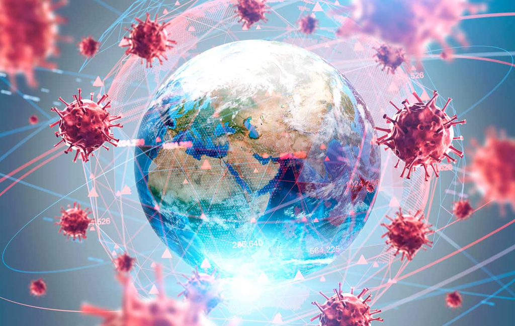

Covid-19 is one of the biggest threats to life expectancy rates in present times. Image Source: Intelsius, link:https://intelsius.com/wp-content/uploads/2020/12/COVID-19-Globe.jpg

This analysis aims to uncover patterns in global health data to answer the following research questions:

1. How does the total number of COVID-19 deaths relate to life expectancy across different WHO regions?
2. How has life expectancy changed across different continents in the past few years?

The data for this report was sourced from the WHO Global Health Observatory data repository (https://www.who.int/data/gho) and the WHO Coronavirus (COVID-19) Dashboard (https://covid19.who.int/).

## **2. Data Preparation:**

1. Data Acquisition: The analysis uses two datasets provided by the World Health Organization (WHO). The primary dataset contains global life expectancy figures and was sourced from the WHO’s data repository. The second dataset contains cumulative COVID-19 case and death counts and was sourced from the WHO’s public dashboard.
2. Data Processing: The two datasets required significant processing before they could be used for analysis.

Life Expectancy Data:

-The raw data was filtered to include only observations for “Life expectancy at birth” and for years between 2000 and 2021.

-Columns were selected and renamed for clarity (e.g., GEO_NAME_SHORT became country).

-Observations where the sex was listed as “Total” were removed to allow for a direct comparison between males and females.

COVID-19 Data:

-The dataset was cleaned to select only country names, WHO regions, and cumulative deaths. Columns were renamed for consistency.

Merging:

-The cleaned life expectancy and COVID-19 datasets were merged into a single tibble. This allows for direct comparison between a country’s life expectancy and the impact of the pandemic.

Variable Creation:

-Two new variables were created: decade, which categorizes the year, and covid_impact, a categorical variable that classifies countries into “High” or “Low” impact based on their cumulative COVID-19 deaths.

3. Challenges Faced: The primary challenge was merging the two datasets. Many country names were inconsistent between the two files (e.g., “United States of America” vs. “United States”). This required manual cleaning and recoding of country names to ensure the data could be joined accurately.

## **3.Variable Descriptions:**

Table 1: Variables of Interest in the Final Dataset

[output not shown]

## **4.Univariate analysis:**

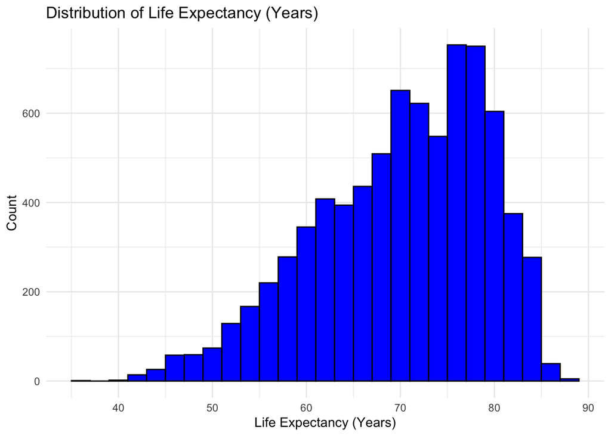

This graph shows the Life Expectancy distribution in years by showing a count of each life expectancy values. It is left skewed with a median of **71.416** and IQR of **13.486**.

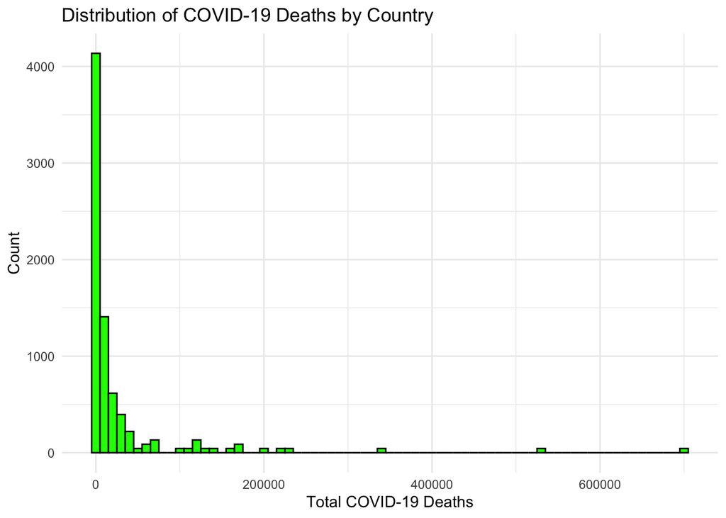

This graph shows the Total Covid-19 deaths distribution by showing a count of each deaths value. The graph is skewed right with a median of **4094** and IQR of **18172.25**.

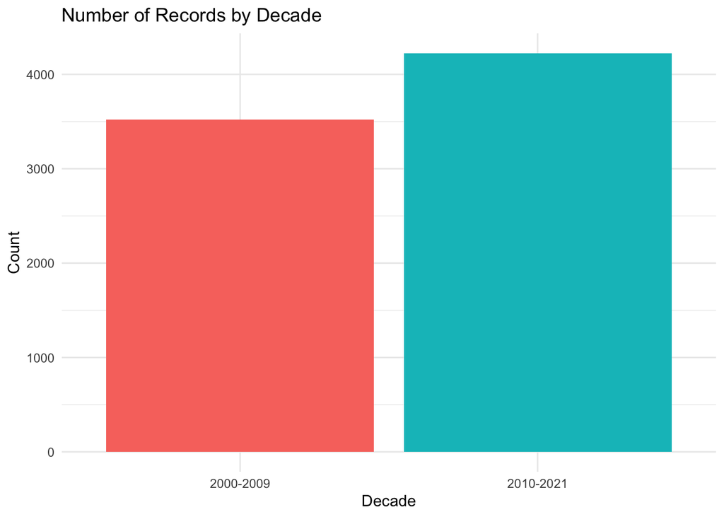

The decade variable shows that most observations fall within the 2010s and 2020s, indicating that the dataset is concentrated in more recent time periods related to the COVID-19 pandemic. The mode is **2010-2021** and the frequency of this column is **4,224 counts**, which represents **54.55** percent of the proportion of the total entries.

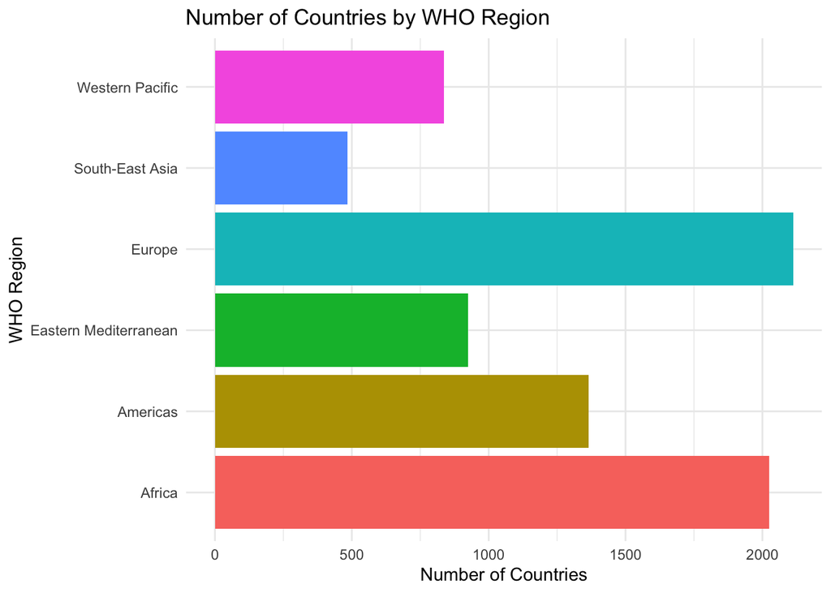

This bar chart shows how many countries belong to each **WHO region**. The **European (EURO)** and **African (AFRO)** regions have the largest number of countries, while regions such as **WP** and **EM** include fewer. This helps illustrate how the dataset is distributed across different parts of the world. The mode is the Europe region with a frequency of 2,112 entries, which represents 27.27 percent of all entrys.

## **5. Bivariate and Multivariate Analyses:**

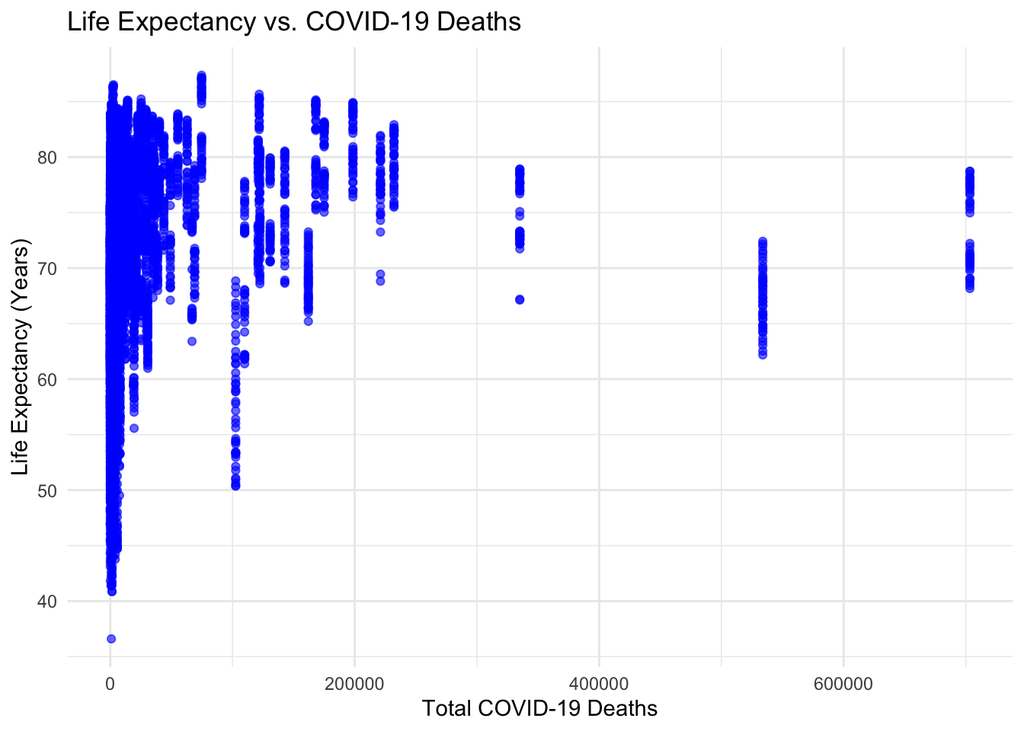

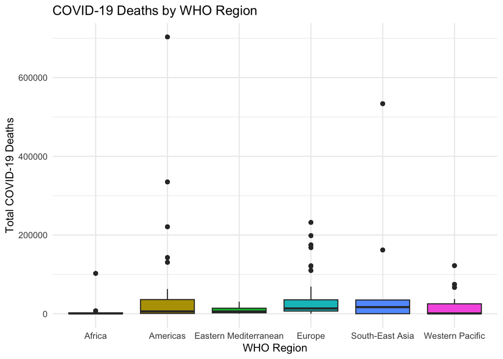

This boxplot compares COVID-19 deaths across different WHO regions. It shows that regions like **Europe (EURO)** and **Americas (AMRO)** generally experienced higher total deaths, while **Africa (AFRO)** and **Western Pacific (WPRO)** had lower totals. This reflects how the pandemic’s severity and reporting varied widely across regions.

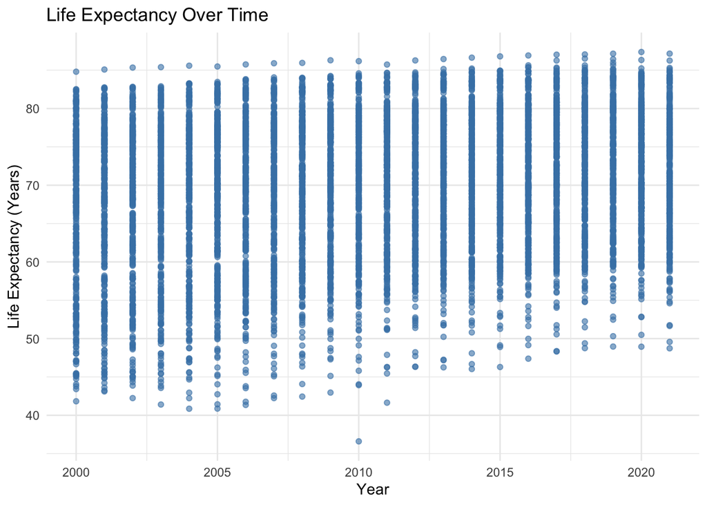

This scatterplot shows how life expectancy has changed over time. The upward pattern suggests that, in general, life expectancy has increased across years, reflecting overall improvements in global health and living conditions. The **correlation coefficient of 0.19** proves that.

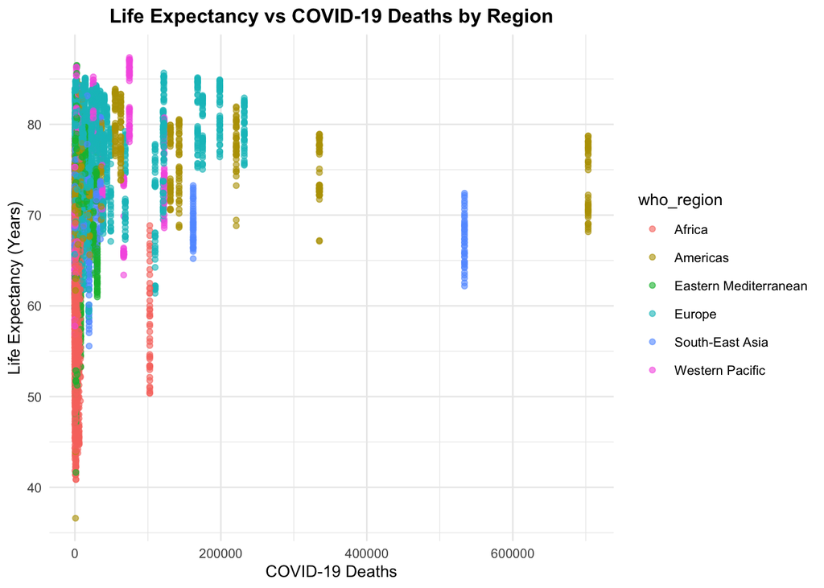

This scatterplot shows the relationship between life expectancy and COVID-19 deaths across different WHO regions. Each color represents a region, and the graph suggests that regions like Europe (EURO) and Western Pacific (WPRO) generally have higher life expectancies, while regions such as Africa (AFRO) tend to have lower life expectancies even with fewer reported deaths. The **correlation coefficient was 0.175**.

## **8. References:**

Covid-19 dataset: https://data.who.int/dashboards/covid19/deaths

Life expectancy dataset:https://data.who.int/indicators/i/A21CFC2/90E2E48

ChatGPT(needed help coding and understanding the process): https://chatgpt.com/auth/login

Wikipedia Covid-19 information:https://en.wikipedia.org/wiki/COVID-19_pandemic_by_country_and_territory?utm_source=chatgpt.com